# Exercises Laboratory Session 06

Nicola Zomer

28 May, 2022

```r
knitr::opts_chunk$set(dev = "ragg_png")
options(digits=5) # set number of digits equal to 5
```

# Packages and functions

```r
# tidyverse
library(tidyverse)

# others
library(kableExtra)
library(glue)
library(latex2exp)
library(scales)
library(R6)

# jags and MCMC
library(rjags)
library(ggmcmc)
library(ggpubr)
```

# Exercise 1

A well established and diffused method for detecting a disease in blood fails to detect the presence of disease in 15% of the patients that actually have the disease. A young UniPD startUp has developed an innovative method of screening. During the qualification phase, a random sample of n = 75 patients known to have the disease is screened using the new method.

I call $p_0=15\%$ the fraction of failures in detecting disease by the standard method.

### (a) What is the probability distribution of y, the number of times the new method fails to detect the disease ?

The number of times $y$ the new method fails is distributed according to a binomial distribution with probability $p$
$$P(y|p, n)=Binom(y|p, n)=\binom{n}{y}p^y(1-p)^{n-y}$$
where $p$ is the probability of failing to the detect the disease.

### (b) On the n=75 patients sample, the new method fails to detect the disease in y=6 cases. What is the frequentist estimator of the failure probability of the new method?

Since the number of failures follows the Binomial distribution, an unbiased frequentist estimator of the failure probability of the new method is
$$\hat{p}_F = \frac{y}{n} = \frac{6}{75} = 0.08$$

### (c) Setup a bayesian computation of the posterior probability, assuming a beta distribution with mean value 0.15 and standard deviation 0.14. Plot the posterior distribution of *p*, and mark on the plot the mean value and variance.

The prior is a Beta distribution with $m=0.15$ and $\sigma=0.14$. For a Beta distribution
$$m=\frac{\alpha}{\alpha+\beta}\quad , \quad
\sigma^2=\frac{\alpha\beta}{(\alpha+\beta)^2(\alpha+\beta+1)}$$
so it is possible to compute $\alpha$ and $\beta$ given $m$ and $\sigma$
$$\begin{align}
\alpha&=-\frac{m(\sigma^2+m^2-m)}{\sigma^2} = 0.83 \\
\beta&=\frac{(\sigma^2+m^2-m)(m-1)}{\sigma^2} = 4.68
\end{align}$$
Since the likelihood is Binomial and a Beta prior is a conjugate function for the Binomial distribution, then the posterior is also a Beta distribution with parameters
$$\begin{align}
\alpha'&=\alpha+y = \alpha + 6 = 6.83 \\
\beta'&=\beta+n-y = \beta +75-6 = \beta+69 = 73.68
\end{align}$$
The mean value and the variance of the posterior are simply
$$\begin{align}
m&=\frac{\alpha'}{\alpha'+\beta'} = 0.0848\\
\sigma^2&=\frac{\alpha'\beta'}{(\alpha'+\beta')^2(\alpha'+\beta'+1)}
= 0.000952
\end{align}$$

```r
xsize= 400
x <- seq(0, 1, length=xsize)

m <- 0.15
sigma <- 0.14

alpha.prior <- -m*(sigma^2+m^2-m)/sigma^2
beta.prior  <- (sigma^2+m^2-m)*(m-1)/sigma^2

alpha.posterior <- alpha.prior + 6
beta.posterior  <- beta.prior + 69

m.posterior <- alpha.posterior/(alpha.posterior+beta.posterior)
var.posterior <- (alpha.posterior*beta.posterior)/((alpha.posterior+beta.posterior)^2*(alpha.posterior+beta.posterior+1))

glue(
  'Posterior parameters:
  - alpha = {round(alpha.posterior, 2)}
  - beta  = {round(beta.posterior, 2)}\n
  Mean value = {round(m.posterior, 4)}
  Variance   = {round(var.posterior, 6)}'
)
```

```
## Posterior parameters:
## - alpha = 6.83
## - beta  = 73.68
##
## Mean value = 0.0848
## Variance   = 0.000952
```

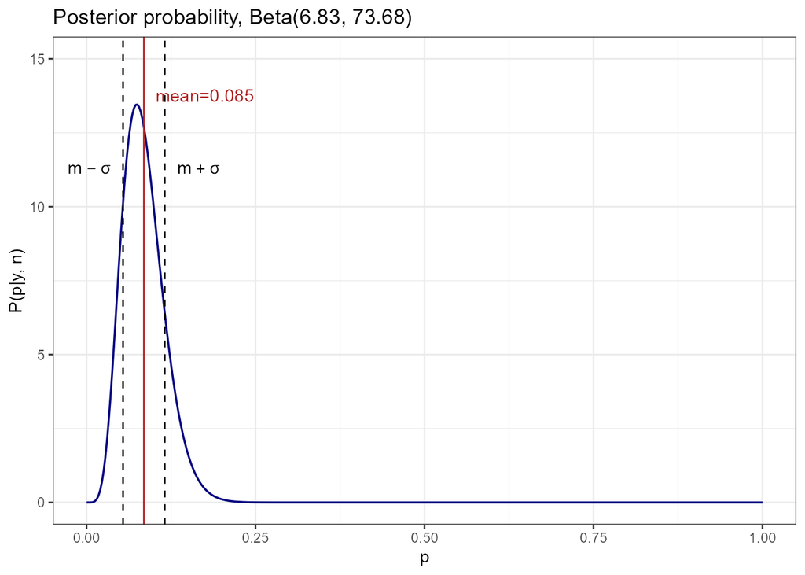

```r
ggplot()+
  geom_line(aes(x, dbeta(x, alpha.posterior, beta.posterior)), color='navyblue', size=0.6)+
  geom_vline(xintercept=m.posterior, color='firebrick')+
  geom_vline(xintercept=m.posterior+c(sqrt(var.posterior), -sqrt(var.posterior)), color='black', linetype='dashed')+
  annotate('text', x=m.posterior+0.09, y=13.75, label=paste('mean=', round(m.posterior, 3), sep=''), color='firebrick')+
  annotate('text', x=m.posterior+sqrt(var.posterior)+0.05, y=11.25, label=TeX('$m+\\sigma$'))+
  annotate('text', x=m.posterior-sqrt(var.posterior)-0.05, y=11.25, label=TeX('$m-\\sigma$'))+
  labs(
    x='p',
    y='P(p|y, n)',
    title=paste('Posterior probability, Beta(', round(alpha.posterior, 2), ', ', round(beta.posterior, 2), ')', sep='')
  )+
  xlim(0, 1)+
  ylim(0, 15)+
  theme_bw()
```

### (d) Perform a test of hypothesis assuming that if the probability of failing to the detect the desease in ill patients is greater or equal than 15%, the new test is no better that the traditional method. Test the sample at a 5% level of significance in the Bayesian way.

The null-hypothesis is
$$H_0: p\geq 15\%$$

while the alternative hypothesis (the new method is better) is
$$H_1: p<15\%$$
The level of significance is chosen to be $\alpha=5\%$.

Using the Bayesian approach, I can compute the posterior probability of $H_0$ by integrating the posterior $p$ over the required region:
$$P(H_0: p\geq15\%) = \int_{0.15}^{1}f(p|y, n)dp = 1-F(p=0.15|y, n)$$
where $F$ is the cumulative distribution of the posterior.

```r
post.H0 <- 1-pbeta(0.15, alpha.posterior, beta.posterior)
glue('Probability P(p>=0.15|y=6, n=75) = {round(post.H0, 4)} = {round(post.H0*100, 2)}%')
```

```
## Probability P(p>=0.15|y=6, n=75) = 0.0313 = 3.13%
```

The result is smaller than $\alpha=5\%$, therefore I reject the null hypothesis at the 5% level of significance and I assume that statistically the new test is better that the traditional one.

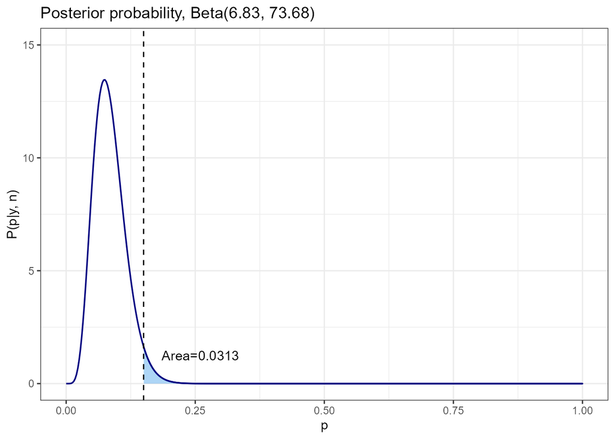

```r
x.area <- tail(x, round(xsize*(1-0.15), 0))

ggplot()+
  geom_line(aes(x, dbeta(x, alpha.posterior, beta.posterior)), color='navyblue', size=0.6)+
  geom_area(aes(x.area, dbeta(x.area, alpha.posterior, beta.posterior)), fill='steelblue2', color='navyblue', alpha=0.5, size=0.6)+
  geom_vline(xintercept=0.15, color='black', linetype='dashed')+
  annotate('text', x=0.15+0.11, y=1.25, label=paste('Area=', round(post.H0, 4), sep=''))+
  labs(
    x='p',
    y='P(p|y, n)',
    title=paste('Posterior probability, Beta(', round(alpha.posterior, 2), ', ', round(beta.posterior, 2), ')', sep='')
  )+
  xlim(0, 1)+
  ylim(0, 15)+
  theme_bw()
```

### (e) Perform the same hypothesis test in the classical frequentist way.

The classical frequentist way is based on the Neyman and Pearson approach. The rejection region is chosen so that the distribution of the null hypothesis is under the significance level $\alpha$, where in this case the null distribution is $Binom(y|p=0.15, n=75)$.

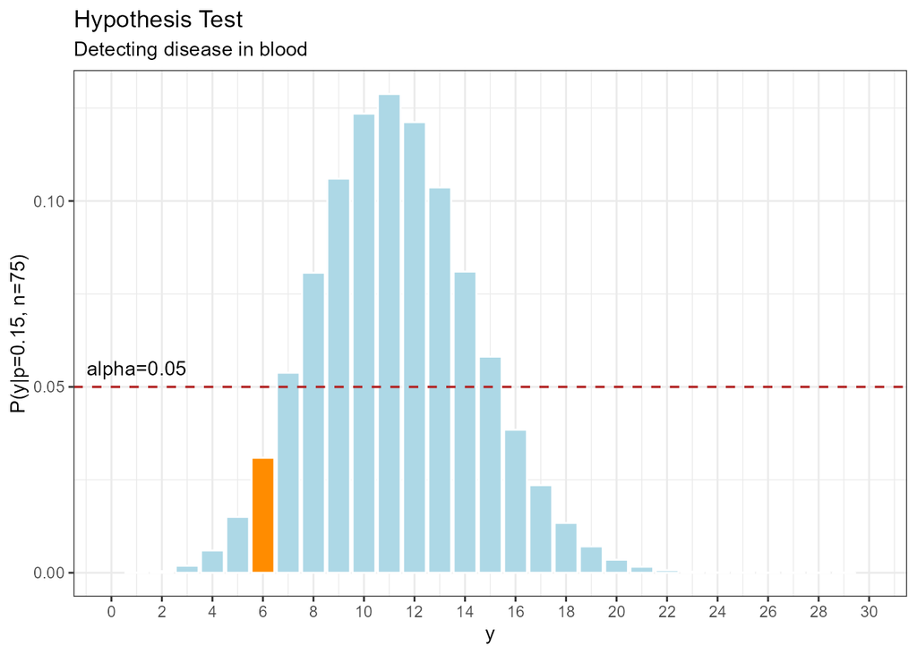

```r
p0 <- 0.15
y_ <- seq(0, 30)

ggplot()+
  geom_col(aes(x=y_, y=dbinom(y_, 75, p0)), color='white', fill='lightblue', alpha=1)+
  geom_col(aes(x=6, y=dbinom(6, 75, p0)), color='white', fill='darkorange')+
  geom_hline(yintercept=0.05, color='firebrick', linetype='dashed', size=0.6)+
  annotate('text', x=1, y=0.055, label='alpha=0.05')+
  labs(
    x='y',
    y=paste('P(y|p=', p0, ', n=75)', sep=''),
    title='Hypothesis Test',
    subtitle='Detecting disease in blood'
  )+
  scale_x_continuous(breaks=seq(0,30, by=2), limits=c(0, 30))+
  theme_bw()
```

```r
glue('Value in y=6: {round(dbinom(6, 75, p0), 4)} < 0.05')
```

```
## Value in y=6: 0.0309 < 0.05
```

Instead, following Fisher’s approach, to decide whether to accept or reject the null hypothesis, it is necessary to calculate the p-value, which in this case (one-side hypothesis test) is given by
$$\text{p-value} = \sum_{y=0}^{6} P(y|p_0, n) = \sum_{y=0}^{6}
Binom(y|p_0, n)$$

```r
glue('p-value: {round(pbinom(6, 75, p0), 4)}')
```

```
## p-value: 0.0544
```

# Exercise 2

Ladislaus Josephovich Bortkiewicz was a Russian economist and statistician. He noted that the Poisson distribution can be very useful in applied statistics when describing low-frequency events in a large population. In a famous example he showed that the number of deaths by horse kick among the Prussian army follows the Poisson distribution.

| y death soldiers | 0 | 1 | 2 | 3 | 4 | $\geq$ 5 |
| --- | --- | --- | --- | --- | --- | --- |
| $n_1$ observations | 109 | 65 | 22 | 3 | 1 | 0 |
| $n_2$ observations | 144 | 91 | 32 | 11 | 2 | 0 |

### (a) Assuming a uniform prior, compute and plot the posterior distribution for $\lambda$, the death rate over the measurement time. Determine the posterior mean, median and variance, and compute the 95% credibility interval.

Assuming a uniform prior for a Poisson process, the posterior becomes a $Gamma(\alpha, \beta)$ function with shape $\alpha=\sum y_i + 1$ and rate $\beta=n$, the number of observations. I want to keep the 2 observations, n1 and n2, separated, so I will compute the posterior distribution for lambda for each set of measurements independently.

To solve the problem, I need the following quantities:

$$\begin{align}
n_{1, \text{tot}} &= \sum_{i=0}^5 (n_1)_i \\
n_{2, \text{tot}} &= \sum_{i=0}^5 (n_2)_i \\
\sum (y_1)_i &= \sum_{i=0}^5 i\cdot(n_1)_i \\
\sum (y_2)_i &= \sum_{i=0}^5 i\cdot(n_2)_i
\end{align}$$

```r
# GENERAL FUNCTIONS
gamma.mean <- function(shape, rate){
  return(shape/rate)
}
gamma.variance <- function(shape, rate){
  return(shape/rate^2)
}
gamma.median <- function(shape, rate){
  return(qgamma(0.5, shape=shape, rate=rate))
}

gg_post <- function(post.funct, limits, mean, median, Title='Posterior', Subtitle=''){
  lambda <- seq(0.25, 1.25, length=400)
  lambda95 <- seq(limits[1], limits[2], length=400)

  ggplot()+
    geom_line(aes(x=lambda, y=post.funct(lambda)), color='navyblue', size=0.6)+
    geom_area(aes(x=lambda95, y=post.funct(lambda95)), fill='steelblue2', color='navyblue', size=0.6, alpha=0.5)+
    labs(
      title=Title,
      x=TeX('$\\lambda$'),
      y=TeX('$P(\\lambda|\\{y_i\\})$')
    )+
    {if (Subtitle!='') labs(subtitle=Subtitle)}+
    scale_y_continuous(breaks=seq(0, 9, by=3), limits=c(0, 9))+
    geom_vline(xintercept=limits, linetype='dashed', size=0.6)+
    geom_vline(xintercept=mean, linetype='dashed', size=0.6, color='firebrick')+
    annotate('text', x=limits[1]-0.08, y=6.75,
             label=paste('x1=', format(limits[1], digits=2, nsmall=2), sep=''))+
    annotate('text', x=limits[2]+0.08, y=6.75,
             label=paste('x2=', format(limits[2], digits=2, nsmall=2), sep=''))+
    annotate('text', x=mean+0.09, y = 8.25,
             label=paste('mean=', format(round(mean, 2), nsmall = 2), sep=''), color='firebrick')+
    theme_bw()
}

# DATAFRAME
df_horsekick <- data.frame(
  y   = c(0, 1, 2, 3, 4, 5),
  n.1 = c(109, 65, 22, 3, 1, 0),
  n.2 = c(144, 91, 32, 11, 2, 0)
)
```

**Observations 1.**

```r
n1.tot <- sum(df_horsekick$n.1)
s.y.1 <- sum(df_horsekick$n.1*df_horsekick$y)

alpha.hk.unif.1 <- s.y.1+1
beta.hk.1 <- n1.tot

mean.hk.unif.1 <- gamma.mean(alpha.hk.unif.1, beta.hk.1)
variance.hk.unif.1 <- gamma.variance(alpha.hk.unif.1, beta.hk.1)
median.hk.unif.1 <- gamma.median(alpha.hk.unif.1, beta.hk.1)
cred.int.unif.1 <- c(qgamma(0.025, shape=alpha.hk.unif.1, rate=beta.hk.1), qgamma(0.975, alpha.hk.unif.1, beta.hk.1))

gg_post(
  function(x){dgamma(x, shape=alpha.hk.unif.1, rate=beta.hk.1)},
  cred.int.unif.1,
  mean.hk.unif.1,
  median.hk.unif.1,
  Title=paste('Posterior distribution: Gamma(', alpha.hk.unif.1, ', ', beta.hk.1, ')', sep=''),
  Subtitle='Positive uniform prior, observations 1'
)
```

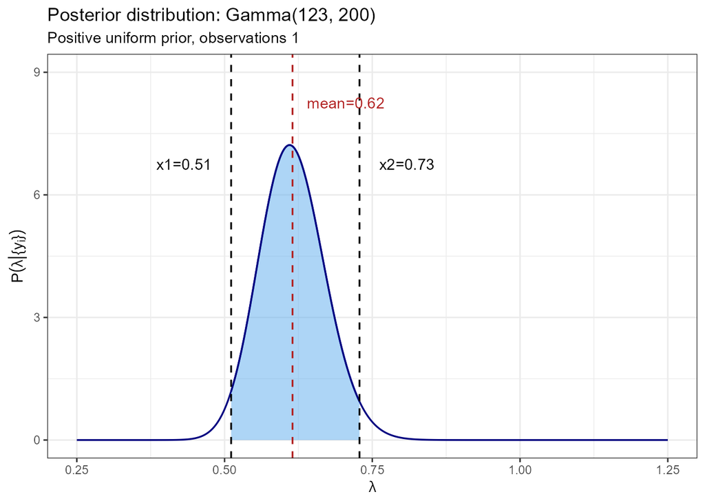

**Observations 2.**

```r
n2.tot <- sum(df_horsekick$n.2)
s.y.2 <- sum(df_horsekick$n.2*df_horsekick$y)

alpha.hk.unif.2 <- s.y.2+1
beta.hk.2 <- n2.tot

mean.hk.unif.2 <- gamma.mean(alpha.hk.unif.2, beta.hk.2)
variance.hk.unif.2 <- gamma.variance(alpha.hk.unif.2, beta.hk.2)
median.hk.unif.2 <- gamma.median(alpha.hk.unif.2, beta.hk.2)
cred.int.unif.2 <- c(qgamma(0.025, shape=alpha.hk.unif.2, rate=beta.hk.2), qgamma(0.975, alpha.hk.unif.2, beta.hk.2))

gg_post(
  function(x){dgamma(x, shape=alpha.hk.unif.2, rate=beta.hk.2)},
  cred.int.unif.2,
  mean.hk.unif.2,
  median.hk.unif.2,
  Title=paste('Posterior distribution: Gamma(', alpha.hk.unif.2, ', ', beta.hk.2, ')', sep=''),
  Subtitle='Positive uniform prior, observations 2'
)
```

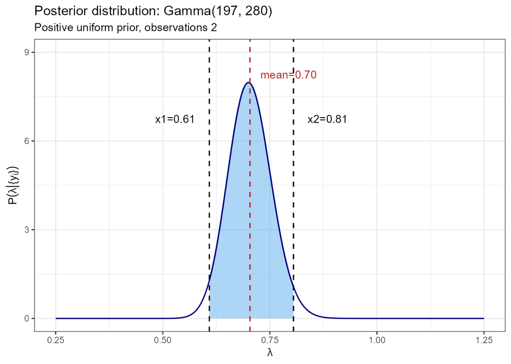

### (b) Assuming now a Jeffrey’s prior, compute and plot the posterior distribution for $\lambda$, the death rate over the measurement time. Determine the posterior mean, median and variance, and compute the 95% credibility interval.

Assuming a Jeffrey’s prior
$$g(\lambda) \propto 1/\sqrt{\lambda}\quad , \quad \text{with }
\lambda>0$$
the posterior is again a $Gamma(\alpha, \beta)$ function and the only difference from the previous case is that now $\alpha=\sum y_i+1/2$. Again, I will distinguish between the 2 measurements.

**Observations 1.**

```r
alpha.hk.jeffrey.1 <- s.y.1+1/2

mean.hk.jeffrey.1 <- gamma.mean(alpha.hk.jeffrey.1, beta.hk.1)
variance.hk.jeffrey.1 <- gamma.variance(alpha.hk.jeffrey.1, beta.hk.1)
median.hk.jeffrey.1 <- gamma.median(alpha.hk.jeffrey.1, beta.hk.1)
cred.int.jeffrey.1 <- c(qgamma(0.025, shape=alpha.hk.jeffrey.1, rate=beta.hk.1), qgamma(0.975, alpha.hk.jeffrey.1, beta.hk.1))

gg_post(
  function(x){dgamma(x, shape=alpha.hk.jeffrey.1, rate=beta.hk.1)},
  cred.int.jeffrey.1,
  mean.hk.jeffrey.1,
  median.hk.jeffrey.1,
  Title=paste('Posterior distribution: Gamma(', alpha.hk.jeffrey.1, ', ', beta.hk.1, ')', sep=''),
  Subtitle="Jeffrey's prior, observations 1"
)
```

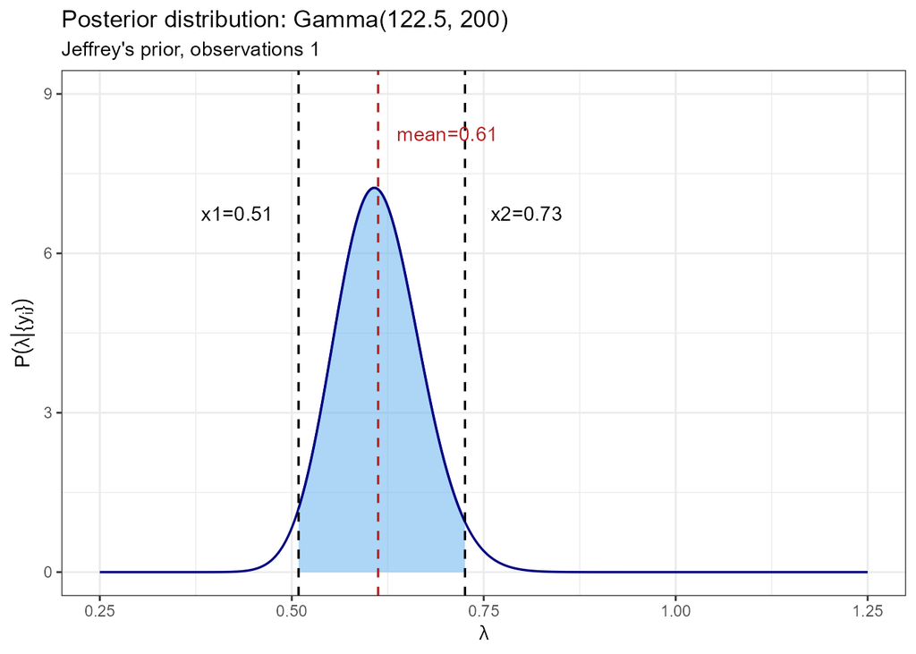

**Observations 2.**

```r
alpha.hk.jeffrey.2 <- s.y.2+1/2

mean.hk.jeffrey.2 <- gamma.mean(alpha.hk.jeffrey.2, beta.hk.2)
variance.hk.jeffrey.2 <- gamma.variance(alpha.hk.jeffrey.2, beta.hk.2)
median.hk.jeffrey.2 <- gamma.median(alpha.hk.jeffrey.2, beta.hk.2)
cred.int.jeffrey.2 <- c(qgamma(0.025, shape=alpha.hk.jeffrey.2, rate=beta.hk.2), qgamma(0.975, alpha.hk.jeffrey.2, beta.hk.2))

gg_post(
  function(x){dgamma(x, shape=alpha.hk.jeffrey.2, rate=beta.hk.2)},
  cred.int.jeffrey.2,
  mean.hk.jeffrey.2,
  median.hk.jeffrey.2,
  Title=paste('Posterior distribution: Gamma(', alpha.hk.jeffrey.2, ', ', beta.hk.2, ')', sep=''),
  Subtitle="Jeffrey's prior, observations 2"
)
```

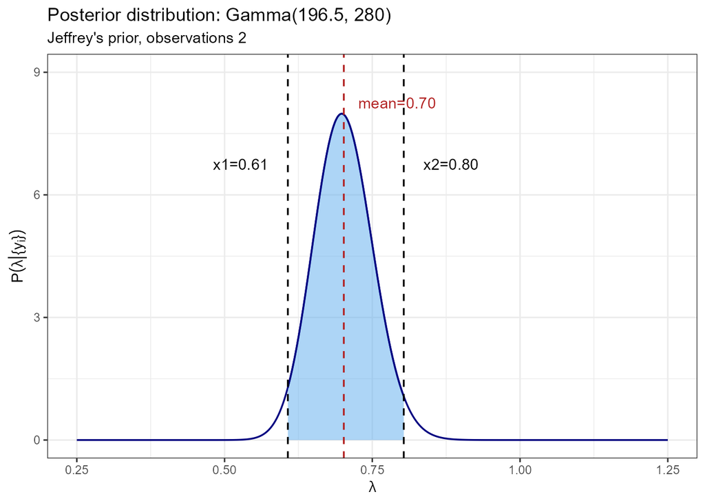

**Summarize the results.**

```r
df_ <- data.frame(
  observation   = rep(1:2, each=2),
  prior         = rep(c('Unif', 'Jeffrey'), 2),
  mean          = c(mean.hk.unif.1, mean.hk.jeffrey.1, mean.hk.unif.2, mean.hk.jeffrey.2),
  median        = c(median.hk.unif.1, median.hk.jeffrey.1, median.hk.unif.2, median.hk.jeffrey.2),
  variance      = c(variance.hk.unif.1, variance.hk.jeffrey.1, variance.hk.unif.2, variance.hk.jeffrey.2),
  Cred.Int.Low  = c(cred.int.unif.1[1], cred.int.jeffrey.1[1], cred.int.unif.2[1], cred.int.jeffrey.2[1]),
  Cred.Int.High = c(cred.int.unif.1[2], cred.int.jeffrey.1[2], cred.int.unif.2[2], cred.int.jeffrey.2[2])
)

df_ %>%
  kable(digits=6) %>%
  kable_styling(full_width=FALSE)
```

| observation | prior | mean | median | variance | Cred.Int.Low | Cred.Int.High |
| --- | --- | --- | --- | --- | --- | --- |
| 1 | Unif | 0.61500 | 0.61333 | 0.003075 | 0.51113 | 0.72834 |
| 1 | Jeffrey | 0.61250 | 0.61083 | 0.003062 | 0.50885 | 0.72562 |
| 2 | Unif | 0.70357 | 0.70238 | 0.002513 | 0.60875 | 0.80516 |
| 2 | Jeffrey | 0.70179 | 0.70060 | 0.002506 | 0.60709 | 0.80325 |

# Exercise 3

In a study on water quality of streams, a high level of bacteria X was defined as a level greater than 100 per 100 ml of stream water. n = 116 samples were taken from streams having a high environmental impact on pandas. Out of these, y = 11 had a high bacteria X level.

### Indicating with $p$ the probability that a sample of water taken from the stream has a high bacteria X level,

### (a) find the frequentist estimator for *p*

Since the sample of water either has or doesn’t have a high bacteria X level, then $y$ follows a Binomial distribution. The frequentist estimator for the Binomial distribution is
$$\hat{p}_F = \frac{y}{n} = \frac{11}{116} \simeq 0.09483$$

### (b) using a *Beta(1; 10)* prior for *p*, calculate and posterior distribution *P(p|y)*

The Beta function is the conjugate prior for the Binomial distribution, so the posterior $P(p|y)$ is also a Beta distribution, with parameters
$$\begin{align}
\alpha'&=\alpha+y = 1+11 = 12 \\
\beta'&=\beta+n-y = 10+116-11 = 115
\end{align}$$

Let’s plot the posterior.

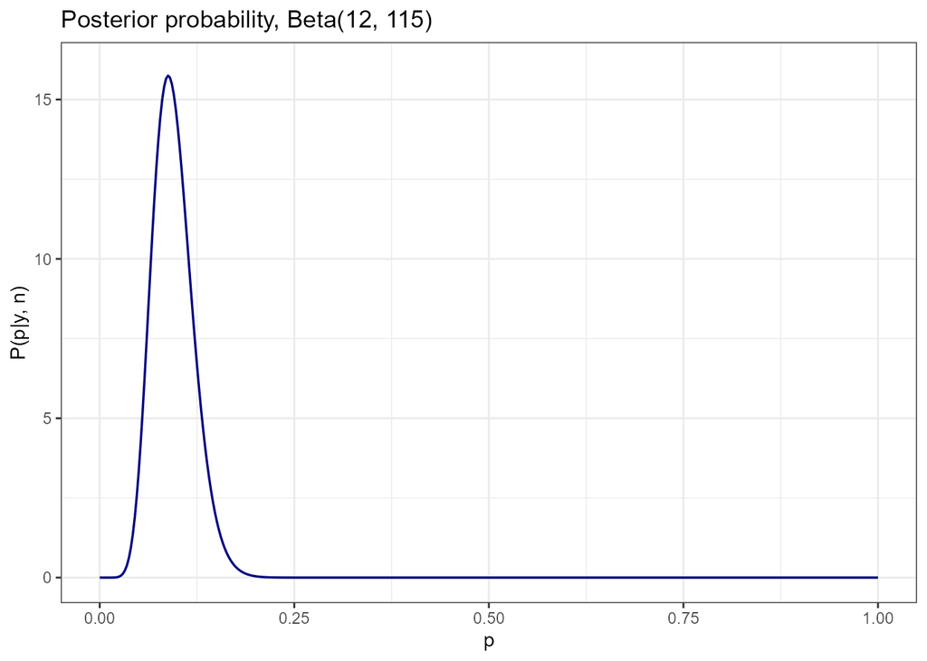

```r
alpha.water <- 12
beta.water  <- 115

xsize= 400
x <- seq(0, 1, length=xsize)

ggplot()+
  geom_line(aes(x, dbeta(x, alpha.water, beta.water)), color='navyblue', size=0.6)+
  labs(
    x='p',
    y='P(p|y, n)',
    title=paste('Posterior probability, Beta(', alpha.water, ', ', beta.water, ')', sep='')
  )+
  xlim(0, 1)+
  ylim(0, 16)+
  theme_bw()
```

### (c) find the bayesian estimator for *p*, the posterior mean and variance, and a 95% credible interval

In the Bayesian approach, the estimator for $p$ is the posterior mean, which in this case is
$$\hat{p}_B = \frac{\alpha'}{\alpha'+\beta'}=\frac{12}{12+115}
\simeq 0.09449$$

```r
# GENERIC FUNCTIONS
beta.mean <- function(alpha_, beta_){
  return(alpha_/(alpha_+beta_))
}
beta.variance <- function(alpha_, beta_){
  return(
    (alpha_*beta_)/((alpha_+beta_)^2*(alpha_+beta_+1))
  )
}
beta.cred.int <- function(alpha_, beta_){
  return(
    c(
      qbeta(0.025, alpha_, beta_),
      qbeta(0.975, alpha_, beta_)
    )
  )
}
```

```r
mean.water <- beta.mean(alpha.water, beta.water)
variance.water <- beta.variance(alpha.water, beta.water)
cred.int.water <- beta.cred.int(alpha.water, beta.water)

df_ <- data.frame(
  mean = mean.water,
  variance = variance.water,
  Cred.Int.Low = cred.int.water[1],
  Cred.Int.High = cred.int.water[2]
)

df_ %>%
  kable(digits=6, caption='Posterior statistics') %>%
  kable_styling(full_width=FALSE)
```

Posterior statistics

| mean | variance | Cred.Int.Low | Cred.Int.High |
| --- | --- | --- | --- |
| 0.094488 | 0.000668 | 0.050185 | 0.15084 |

### (d) test the following hypotesis at 5% level of significance with both the frequentist and bayesian approach

$$H_0: p=0.1 \text{ versus } H_1: p\neq 0.1$$

This requires a two-sides hypothesis test, where the null distribution is the sampling distribution of $y$, given that $H_0$ is true: $Binom(y|n=116, p=0.1)$.

In the Neyman and Pearson approach I simply have to check if $y=11$ lies inside or outside the rejection region, defined as the region in which the probability of $y$ is under the significance level $\alpha$.

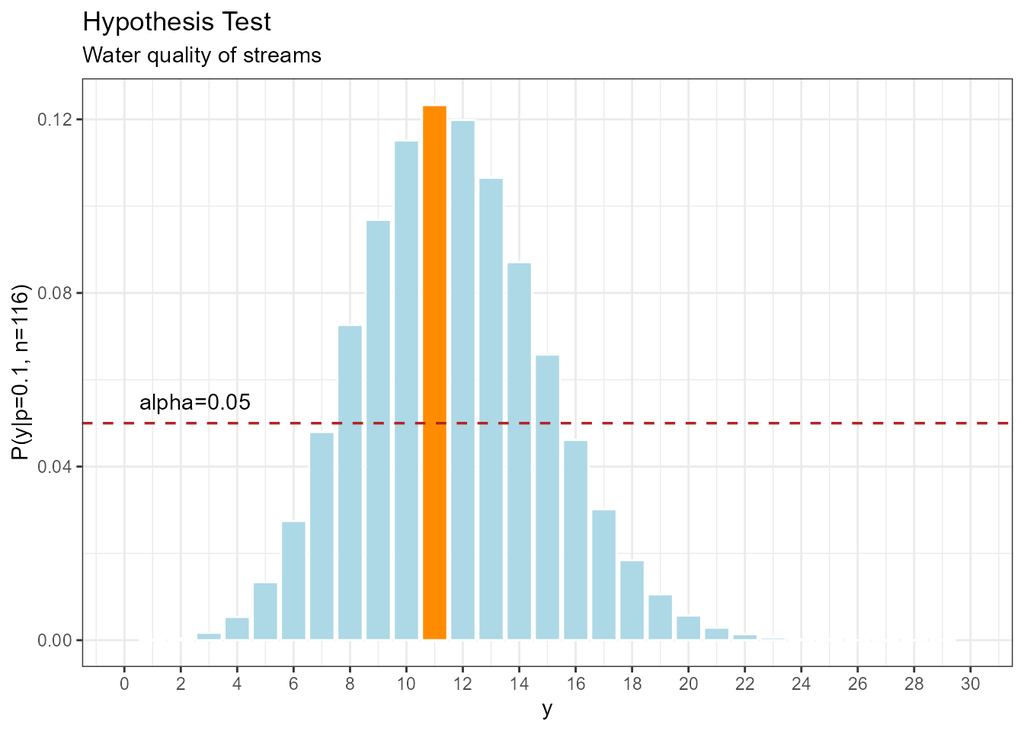

```r
n  <- 116
y  <- 11
p0 <- 0.1

alpha.value <- 0.05

# function to plot the histogram for the hypothesis test
gg_HT <- function(n_, p0_, y_){
  yplot <- seq(0, 30)

  ggplot()+
    geom_col(aes(x=yplot, y=dbinom(yplot, n_, p0_)), color='white', fill='lightblue', alpha=1)+
    geom_col(aes(x=y_, y=dbinom(y_, n_, p0_)), color='white', fill='darkorange')+
    geom_hline(yintercept=alpha.value, color='firebrick', linetype='dashed', size=0.6)+
    annotate('text', x=2.5, y=alpha.value+0.005, label=paste('alpha=', alpha.value, sep=''))+
    labs(
      x='y',
      y=paste('P(y|p=', p0_, ', n=', n_, ')', sep=''),
      title='Hypothesis Test',
      subtitle='Water quality of streams'
    )+
    scale_x_continuous(breaks=seq(0,30, by=2), limits=c(0, 30))+
    theme_bw()
}

gg_HT(n, p0, y)
```

```r
glue('Value in y={y}: {round(dbinom(y, n, p0), 4)} > {alpha.value}')
```

```
## Value in y=11: 0.1233 > 0.05
```

```r
glue('p-value: {round(pbinom(y, n, p0)+1-pbinom(n-y-1, n, p0), 4)} > {alpha.value}')
```

```
## p-value: 0.5043 > 0.05
```

The hypothesis test can be performed also using the Bayesian approach. I assume a $Beta(1, 10)$ function as prior, so the posterior distribution is the same as in point (b). I already computed in point (c) the $(1-\alpha)\cdot 100\%=95\%$ credibility interval for $p$, so to accept or reject the null hypothesis I simply have to check if $p_0=0.1$ lies inside or outside this interval.

```r
glue('95% credibility interval for p: [{round(cred.int.water[1], 4)}, {round(cred.int.water[2], 4)}]')
```

```
## 95% credibility interval for p: [0.0502, 0.1508]
```

$p_0$ lies inside the interval, so also with the Bayesian approach I do not reject the null hypothesis $H_0$.

### A new measurement, performed one month later on n = 165 water samples, gives y = 9 high bacteria X level

### (e) find the frequentist estimator for *p*

For the same reason described in point (a), the frequentist estimator for $p$ is
$$\hat{p}_F = \frac{y}{n} = \frac{9}{165} \simeq 0.054545$$

### (f) find a bayesian estimator for *p*, assuming both a *Beta(1; 10)* prior for *p* and the posterior probability of the older measurement as the prior for the new one.

To find the Bayesian estimator, I must first compute the posterior distribution associated with each of the considered priors. Assuming a $Beta(1,10)$ prior, the posterior $P(p|y)$ is a Beta distribution with parameters
$$\begin{align}
\alpha'&=\alpha+y = 1+9 = 10 \\
\beta'&=\beta+n-y = 10+165-9 = 166
\end{align}$$

Instead, assuming as prior the posterior probability of the older measurement, which was a $Beta(12, 115)$ function, the posterior is again a Beta distribution, in this case with parameters
$$\begin{align}
\alpha'&=\alpha_{old}+y = 12+9 = 21 \\
\beta'&=\beta_{old}+n-y = 115+165-9 = 271
\end{align}$$

**Beta(1, 10) prior**
$$\hat{p}_B = \frac{\alpha'}{\alpha'+\beta'}=\frac{10}{10+166}
\simeq 0.056818$$
**Beta(12, 115) prior, i.e. posterior of the older measurement**
$$\hat{p}_B = \frac{\alpha'}{\alpha'+\beta'}=\frac{21}{21+271}
\simeq 0.071918$$

### (g) find the posterior mean and variance, and a 95% credible interval

```r
alpha.w.1 <- 10
beta.w.1  <- 166

alpha.w.2 <- 21
beta.w.2  <- 271

mean.w.1 <- beta.mean(alpha.w.1, beta.w.1)
variance.w.1 <- beta.variance(alpha.w.1, beta.w.1)
cred.int.w.1 <- beta.cred.int(alpha.w.1, beta.w.1)

mean.w.2 <- beta.mean(alpha.w.2, beta.w.2)
variance.w.2 <- beta.variance(alpha.w.2, beta.w.2)
cred.int.w.2 <- beta.cred.int(alpha.w.2, beta.w.2)

df_ <- data.frame(row.names=c('Beta.1.10', 'Beta.12.115'))
df_['mean'] <- c(mean.w.1, mean.w.2)
df_['variance'] <- c(variance.w.1, variance.w.2)
df_['Cred.Int.Low']  <- c(cred.int.w.1[1], cred.int.w.2[1])
df_['Cred.Int.High'] <- c(cred.int.w.1[2], cred.int.w.2[2])

df_ %>%
  kable(digits=6) %>%
  kable_styling(full_width=FALSE)
```

|  | mean | variance | Cred.Int.Low | Cred.Int.High |
| --- | --- | --- | --- | --- |
| Beta.1.10 | 0.056818 | 0.000303 | 0.027739 | 0.09538 |
| Beta.12.115 | 0.071918 | 0.000228 | 0.045224 | 0.10415 |

Plot of the posteriors:

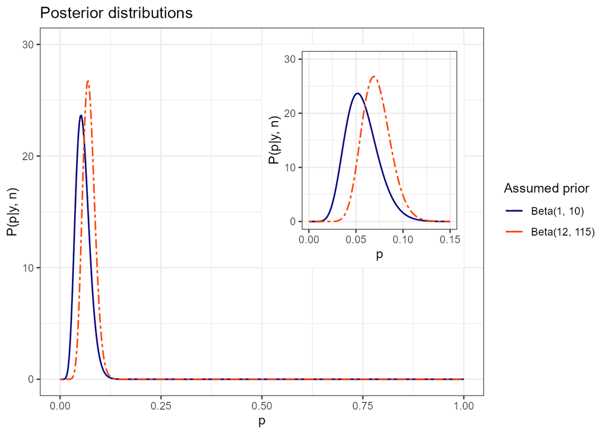

```r
xsize= 400
x <- seq(0, 1, length=xsize)
x.zoom <- seq(0, 0.15, length=xsize)

gg_w_12 <- ggplot()+
  geom_line(aes(x, dbeta(x, alpha.w.1, beta.w.1), color='Beta(1, 10)'), size=0.6)+
  geom_line(aes(x, dbeta(x, alpha.w.2, beta.w.2), color='Beta(12, 115)'), size=0.6, linetype='twodash')+
  labs(
    x='p',
    y='P(p|y, n)',
    title='Posterior distributions'
  )+
  xlim(0, 1)+
  ylim(0, 30)+
  scale_color_manual('Assumed prior', values=c('Beta(1, 10)'='navyblue', 'Beta(12, 115)'='orangered'))+
  theme_bw()

gg_w_12_zoom <- ggplot()+
  geom_line(aes(x.zoom, dbeta(x.zoom, alpha.w.1, beta.w.1)), color='navyblue', size=0.6)+
  geom_line(aes(x.zoom, dbeta(x.zoom, alpha.w.2, beta.w.2)), color='orangered', size=0.6, linetype='twodash')+
  labs(
    x='p',
    y='P(p|y, n)'
  )+
  ylim(0, 30)+
  theme_bw()


gg_w_12 + annotation_custom(ggplotGrob(gg_w_12_zoom), xmin = 0.5, xmax = 1, ymin = 10, ymax = 30)
```

### (h) test the following hypotesis at 5% level of significance with both the frequentist and bayesian approach

$$H_0: p=0.1 \text{ versus } H_1: p\neq 0.1$$

As in point (d), the null distribution is the sampling distribution of $y$, given that $H_0$ is true: $Binom(y|n=165, p=0.1)$.

```r
# useful quantities
n  <- 165
y  <- 9
p0 <- 0.1

alpha.value <- 0.05
```

**Frequentist approach**

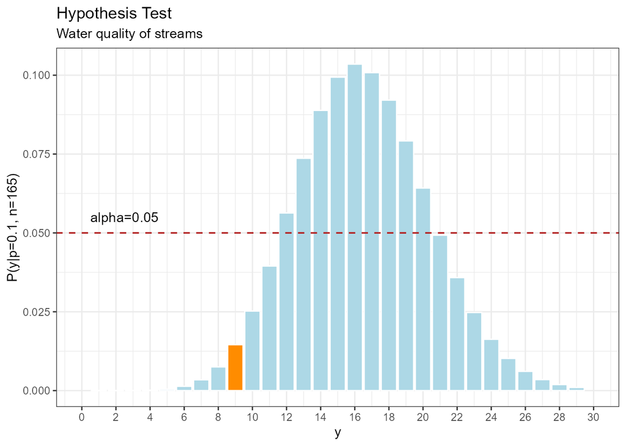

```r
gg_HT(n, p0, y)
```

```r
glue('Value in y={y}: {round(dbinom(y, n, p0), 4)} < {alpha.value}')
```

```
## Value in y=9: 0.0146 < 0.05
```

$y=9$ lies outside the acceptance region, so according to the Neyman and Pearson approach I reject the null hypothesis $H_0$. The same result can be obtained by evaluating the p-value:

```r
glue('p-value: {round(pbinom(y, n, p0)+1-pbinom(n-y-1, n, p0), 4)} < {alpha.value}')
```

```
## p-value: 0.0275 < 0.05
```

**Bayesian approach**  
With the Bayesian approach it is necessary to distinguish between the 2 priors defined in point (f). For each, the null hypothesis is accepted or rejected depending on whether $p_0$ falls inside the 95% credibility interval for $p$ or not.

```r
glue('
  95% credibility interval for p, assuming a Beta(1, 10) prior:
  [{round(cred.int.w.1[1], 4)}, {round(cred.int.w.1[2], 4)}]\n
  95% credibility interval for p, assuming a Beta(12, 115) prior:
  [{round(cred.int.w.2[1], 4)}, {round(cred.int.w.2[2], 4)}]'
)
```

```
## 95% credibility interval for p, assuming a Beta(1, 10) prior:
## [0.0277, 0.0954]
##
## 95% credibility interval for p, assuming a Beta(12, 115) prior:
## [0.0452, 0.1042]
```

The result is different in the two cases, in fact in the first $p_0=0.1$ lies outside the interval, while in the second it falls inside. So, with Bayesian approach I reject the null hypothesis when using a $Beta(1, 10)$ prior, while I accept it when using as prior the posterior of the older measurement. This is reasonable, as $p_0$ is very close to the upper bounds of both 95% credibility intervals and in the second case the prior and the posterior are both slightly shifted towards larger values of $p$.

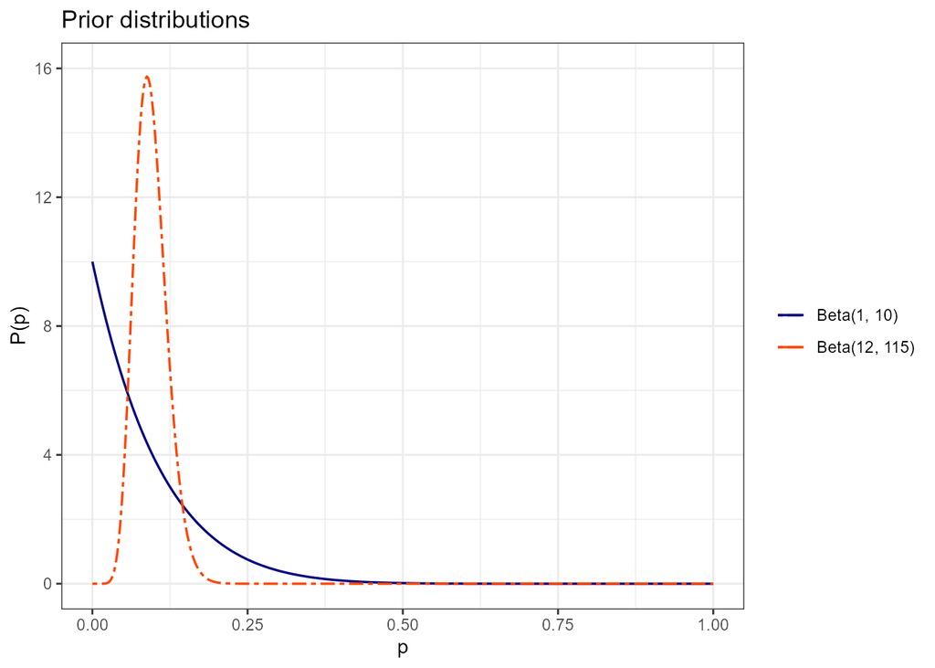

```r
ggplot()+
  geom_line(aes(x, dbeta(x, 1, 10), color='Beta(1, 10)'), size=0.6)+
  geom_line(aes(x, dbeta(x, 12, 115), color='Beta(12, 115)'), size=0.6, linetype='twodash')+
  labs(
    x='p',
    y='P(p)',
    title='Prior distributions'
  )+
  xlim(0, 1)+
  scale_y_continuous(breaks=seq(0, 16, by=4), limits=c(0, 16))+
  scale_color_manual('', values=c('Beta(1, 10)'='navyblue', 'Beta(12, 115)'='orangered'))+
  theme_bw()+
  theme(legend.title=element_blank())
```

# MCMC (JAGS) object

Starting with the coda output, here I define an `R6` object which uses the `ggmcmc` package to perform the chain analysis and display the results of MCMC. Some methods are just wrappers around the built-in `ggmcmc` functions.

```r
chainR6 <- R6Class(
  'chainR6',
  public = list(
    param = NULL,       # string
    chain.ggs = NULL,   # coda.samples object
    cred.int  = NULL,   # credibility interval

    initialize = function(chain_, param){
      self$param <- param
      self$chain.ggs <- ggs(chain_)
    },

    # plot the chains
    traceplot = function(title=''){
      ggs_traceplot(self$chain.ggs)+
        geom_line(color='steelblue')+
        labs(
          x='Iteration',
          y='Value'
        )+
        {if (title!='') labs(title=title)}+
        theme_bw()
    },

    # plot the density of the parameter
    density = function(title=''){
      self$chain.ggs %>%
        filter(Parameter==self$param) %>%
        ggs_density()+
          geom_density(color='steelblue', fill='lightblue', alpha=0.6)+
          labs(
            x='Value',
            y='Density'
          )+
          {if (title!='') labs(title=title)}+
          theme_bw()
    },

    # plot running mean
    running = function(title=''){
      ggs_running(self$chain.ggs)+
        {if (title!='') labs(title=title)}+
        theme_bw()+
        theme(legend.position="none")
    },

    # plot autocorrelation
    autocorrelation = function(title=''){
      ggs_autocorrelation(self$chain.ggs)+
        geom_col(fill='steelblue')+
        {if (title!='') labs(title=title)}+
        theme_bw()
    },

    # plot the histogram of p, with the credibility interval
    inference = function(y.cred.int=1, ci.round=3, subtitle='', xlim, ylim){

      self$cred.int <- (
        ci(self$chain.ggs, thick_ci = c(0.05, 0.95), thin_ci = c(0.025, 0.975))[1,c('low','high')]
      )

      self$chain.ggs %>%
        filter(Parameter==self$param) %>%
        ggplot(aes(x=value))+
          geom_histogram(aes(y=..density..), bins=40, color='white', fill='forestgreen')+
          geom_segment(aes(x = self$cred.int$low, y = 0, xend = self$cred.int$high, yend = 0),
                       size=2.5, color='darkred')+
          annotate('label', x=(self$cred.int$low+self$cred.int$high)/2, y=y.cred.int,
                   label='95% Cred. Int.', size=6, fill='white', alpha=0.8)+
          annotate('label', x=self$cred.int$low, y=y.cred.int,
                   label=paste(round(self$cred.int$low, ci.round)),  size=6, fill='white', alpha=0.8)+
          annotate('label', x=self$cred.int$high, y=y.cred.int,
                   label=paste(round(self$cred.int$high, ci.round)), size=6, fill='white', alpha=0.8)+
          labs(
           x=self$param,
           y=paste('f(', self$param, ')', sep=''),
           title=paste('Inference on ', self$param, sep='')
          )+
          {if (!missing(xlim)) xlim(xlim[1], xlim[2])}+
          {if (!missing(ylim)) ylim(ylim[1], ylim[2])}+
          {if (subtitle!='') labs(subtitle=subtitle)}+
          theme_bw()
    },

    # plot the predictions of y
    prediction = function(binomial=FALSE, n.next=NA, x.plot.max=NA, subtitle=''){
      if (binomial){
        Title <- paste('Number of successes in ', n.next, ' future trials', sep='')
        xmax  <- n.next
      } else{
        Title <- 'Predicted counts'
        xmax  <- x.plot.max
      }

      self$chain.ggs %>%
        filter(Parameter=='y') %>%
        ggplot(aes(x=value))+
          geom_bar(aes(y = ..prop..), color='black', fill='firebrick')+
          labs(
            x='y',
            y='f(y)',
            title=Title
          )+
          {if (subtitle!='') labs(subtitle=subtitle)}+
          scale_x_continuous(breaks=seq(0, xmax, by=1))+
          theme_bw()
    },

    # plot correlation between p and y
    correlation = function(x.min, x.max, y.min, y.max, subtitle=''){
      self$chain.ggs %>%
        summarise(
          y=value[Parameter=='y'],
          p=value[Parameter==self$param]
        )%>%
        ggplot()+
          geom_point(aes(x=p, y=y), color='navyblue', shape=3)+
          labs(
            title=paste('Correlation between ', self$param, ' and the predicted variable', sep='')
          )+
          {if (subtitle!='') labs(subtitle=subtitle)}+
          xlim(x.min, x.max)+
          scale_y_continuous(breaks=seq(y.min, y.max, by=2), limits=c(y.min, y.max))+
          theme_bw()
    }
  )
)
```

# General comments on the results of all the following exercises

In exercises 4, 5 and 6 I run MCMC with JAGS. In all of these it is possible to notice that the chains behave correctly, the average values of $p$ (or $\lambda$) and $y$ converge rapidly and the autocorrelation scales well with the lag. Regarding the inference of $p$ (or $\lambda$), it is possible to see that the posterior distributions found with JAGS are compatible with the corresponding ones found analytically in the previous exercises (very similar shape, mean/mode, credibility interval).

# Exercise 4

Analyze the data of Exercise 1 using a MCMC with JAGS (solve only point c of Ex 1). Notice that in the Exercise 1 we are dealing with a Bernoulli process, but we only know the number of successes out of $n$ trials.

### JAGS model

```r
modelpath_e4 <- "./bugs_models/model_ex4.bug"

model_string <- "model {
    # data likelihood (prob of y given p and n)
    X ~ dbin(p, n);

    # beta prior for p
    p ~ dbeta(alpha, beta);

    # predicted data , given p and the number of samples
    y ~ dbin(p, n_next);
}
"

writeLines(model_string , con=modelpath_e4)
```

### Run MCMC and plot the results

```r
data <- NULL
data$X <- 6       # number of observations
data$n <- 75      # number of patients screened
data$n_next <- 10 # predictions (10 more data)

data$alpha <- alpha.prior
data$beta  <- beta.prior

jm <- jags.model(file=modelpath_e4, data=data, n.chains=1, n.adapt=500)
update(jm, 1000)
chain <- coda.samples(jm, c("p", "y"), n.iter=10000)
print(summary(chain))
```

```
##
## Iterations = 1501:11500
## Thinning interval = 1
## Number of chains = 1
## Sample size per chain = 10000
##
## 1. Empirical mean and standard deviation for each variable,
##    plus standard error of the mean:
##
##     Mean     SD Naive SE Time-series SE
## p 0.0849 0.0305 0.000305       0.000427
## y 0.8392 0.9244 0.009244       0.009594
##
## 2. Quantiles for each variable:
##
##     2.5%    25%    50%   75% 97.5%
## p 0.0354 0.0628 0.0812 0.103 0.155
## y 0.0000 0.0000 1.0000 1.000 3.000
```

```r
# Correlation matrix
cat("Correlation matrix: \n")
```

```
## Correlation matrix:
```

```r
as.data.frame(as.mcmc(chain)) %>%
  cor() %>%
  print()
```

```
##         p       y
## p 1.00000 0.33263
## y 0.33263 1.00000
```

```r
chain_e4 <- chainR6$new(chain, param='p')
```

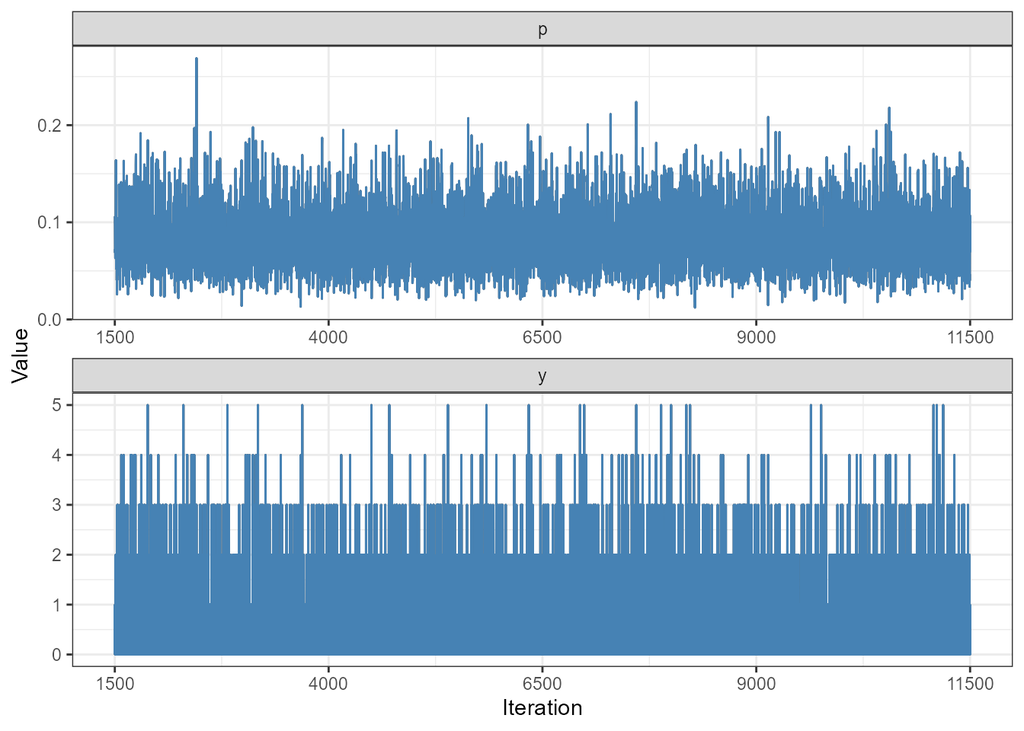

```r
chain_e4$traceplot()
```

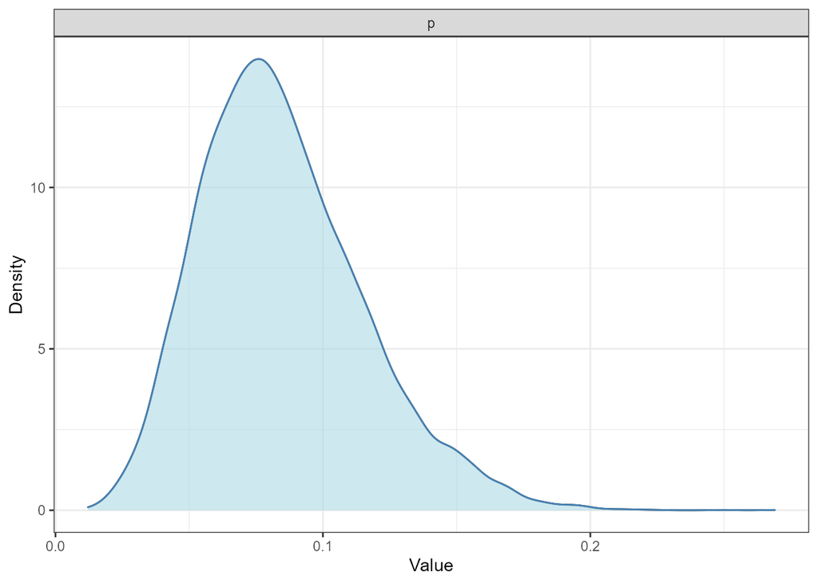

```r
chain_e4$density()
```

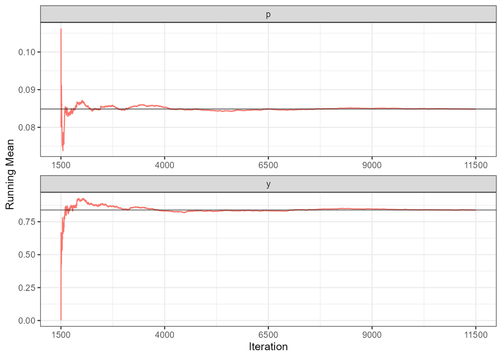

```r
chain_e4$running()
```

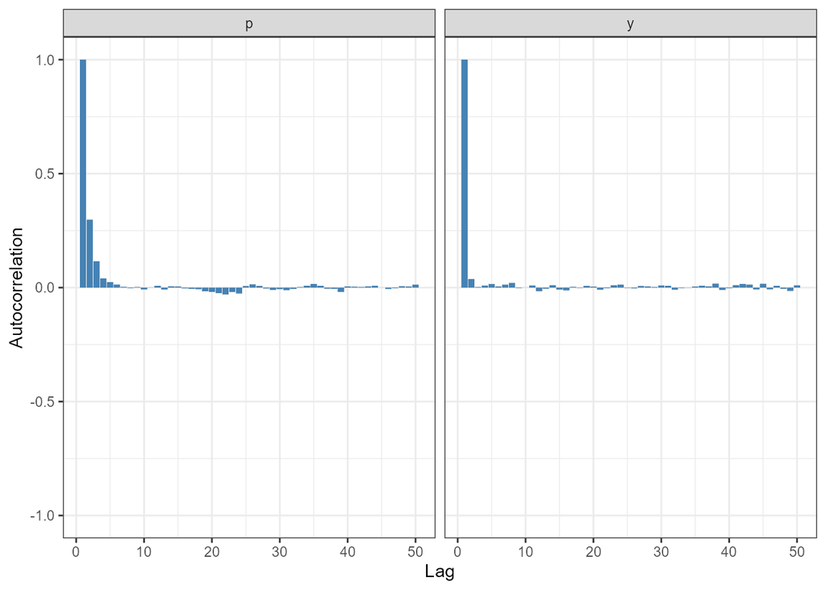

```r
chain_e4$autocorrelation()
```

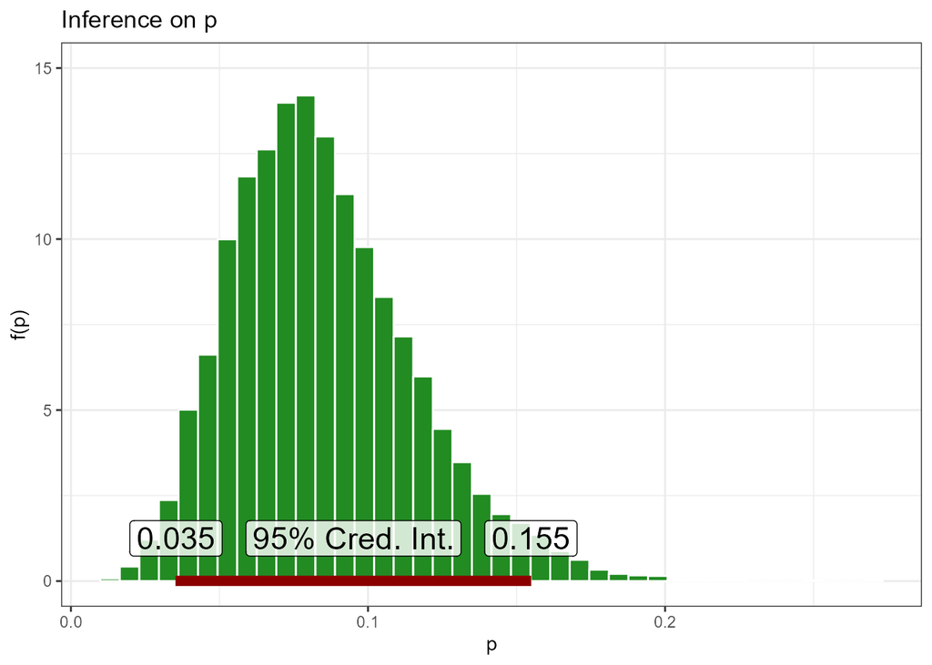

```r
chain_e4$inference(y.cred.int=1.25, ylim=c(0, 15))
```

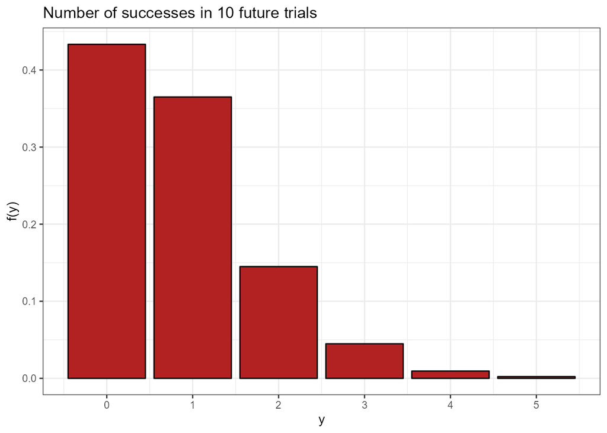

```r
chain_e4$prediction(binomial=TRUE, n.next=data$n_next)
```

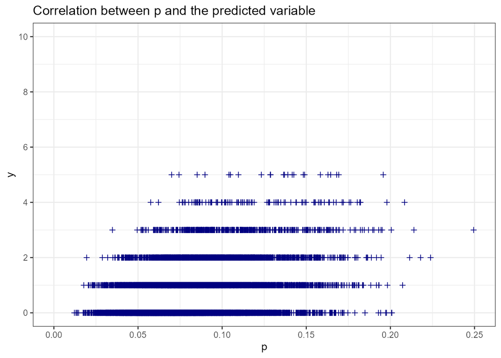

```r
chain_e4$correlation(x.min=0, x.max=0.25, y.min=0, y.max=data$n_next)
```

# Exercise 5

Analyze the data of Exercise 2 using a MCMC with JAGS.

### JAGS model

```r
modelpath_e5 <- "./bugs_models/model_ex5.bug"

model_string <- "model {
    # data likelihood
    for (i in 1:length(X)) {
      X[i] ~ dpois(lambda);
    }

    # uniform prior for lambda
    lambda ~ dunif(min.prior, max.prior)

    # predicted data , given lambda
    y ~ dpois(lambda);
}
"

writeLines(model_string, con=modelpath_e5)
```

### Run MCMC and plot the results

In this case, given the table in exercise 02, I need to generate the data, repeating each value of $y$ the corresponding number of times ($n_1$ or $n_2$). Furthermore, I have to distinguish between the 2 sets of observations.

```r
df_horsekick %>%
  kable() %>%
  kable_styling(full_width=FALSE)
```

| y | n.1 | n.2 |
| --- | --- | --- |
| 0 | 109 | 144 |
| 1 | 65 | 91 |
| 2 | 22 | 32 |
| 3 | 3 | 11 |
| 4 | 1 | 2 |
| 5 | 0 | 0 |

```r
obs.1 <- rep(df_horsekick$y, df_horsekick$n.1)
obs.2 <- rep(df_horsekick$y, df_horsekick$n.2)

cat('Observations 1:\n', obs.1, '\n\nObservations 2:\n', obs.2)
```

```
## Observations 1:
##  0 0 0 0 0 0 0 0 0 0 0 0 0 0 0 0 0 0 0 0 0 0 0 0 0 0 0 0 0 0 0 0 0 0 0 0 0 0 0 0 0 0 0 0 0 0 0 0 0 0 0 0 0 0 0 0 0 0 0 0 0 0 0 0 0 0 0 0 0 0 0 0 0 0 0 0 0 0 0 0 0 0 0 0 0 0 0 0 0 0 0 0 0 0 0 0 0 0 0 0 0 0 0 0 0 0 0 0 0 1 1 1 1 1 1 1 1 1 1 1 1 1 1 1 1 1 1 1 1 1 1 1 1 1 1 1 1 1 1 1 1 1 1 1 1 1 1 1 …
##
## Observations 2:
##  0 0 0 0 0 0 0 0 0 0 0 0 0 0 0 0 0 0 0 0 0 0 0 0 0 0 0 0 0 0 0 0 0 0 0 0 0 0 0 0 0 0 0 0 0 0 0 0 0 0 0 0 0 0 0 0 0 0 0 0 0 0 0 0 0 0 0 0 0 0 0 0 0 0 0 0 0 0 0 0 0 0 0 0 0 0 0 0 0 0 0 0 0 0 0 0 0 0 0 0 0 0 0 0 0 0 0 0 0 0 0 0 0 0 0 0 0 0 0 0 0 0 0 0 0 0 0 0 0 0 0 0 0 0 0 0 0 0 0 0 0 0 0 0 1 1 1 1 …
```

**Observations 1.**

```r
data <- NULL

data$X <- obs.1
data$min.prior <- 0
data$max.prior <- 10

jm <- jags.model(file=modelpath_e5, data=data, n.chains=1, n.adapt=500)
update(jm, 1000)
chain <- coda.samples(jm, c("lambda", "y"), n.iter=10000)
print(summary(chain))
```

```
##
## Iterations = 1501:11500
## Thinning interval = 1
## Number of chains = 1
## Sample size per chain = 10000
##
## 1. Empirical mean and standard deviation for each variable,
##    plus standard error of the mean:
##
##         Mean     SD Naive SE Time-series SE
## lambda 0.615 0.0554 0.000554        0.00068
## y      0.618 0.7916 0.007916        0.00842
##
## 2. Quantiles for each variable:
##
##         2.5%   25%   50%   75% 97.5%
## lambda 0.511 0.577 0.614 0.651 0.728
## y      0.000 0.000 0.000 1.000 3.000
```

```r
# Correlation matrix
cat("Correlation matrix: \n")
```

```
## Correlation matrix:
```

```r
as.data.frame(as.mcmc(chain)) %>%
  cor() %>%
  print()
```

```
##         lambda       y
## lambda 1.00000 0.07345
## y      0.07345 1.00000
```

```r
chain_e5_1 <- chainR6$new(chain, param='lambda')
```

**Observations 2.**

```r
data <- NULL

data$X <- obs.2
data$min.prior <- 0
data$max.prior <- 10

jm <- jags.model(file=modelpath_e5, data=data, n.chains=1, n.adapt=500)
update(jm, 1000)
chain <- coda.samples(jm, c("lambda", "y"), n.iter=10000)
print(summary(chain))
```

```
##
## Iterations = 1501:11500
## Thinning interval = 1
## Number of chains = 1
## Sample size per chain = 10000
##
## 1. Empirical mean and standard deviation for each variable,
##    plus standard error of the mean:
##
##         Mean     SD Naive SE Time-series SE
## lambda 0.702 0.0504 0.000504       0.000646
## y      0.694 0.8304 0.008304       0.008304
##
## 2. Quantiles for each variable:
##
##         2.5%   25%   50%   75% 97.5%
## lambda 0.607 0.668 0.702 0.735 0.804
## y      0.000 0.000 1.000 1.000 3.000
```

```r
# Correlation matrix
cat("Correlation matrix: \n")
```

```
## Correlation matrix:
```

```r
as.data.frame(as.mcmc(chain)) %>%
  cor() %>%
  print()
```

```
##          lambda        y
## lambda 1.000000 0.044954
## y      0.044954 1.000000
```

```r
chain_e5_2 <- chainR6$new(chain, param='lambda')
```

### Chain analysis and results

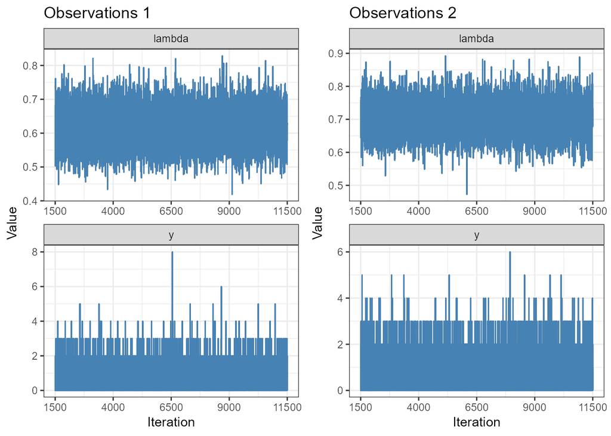

```r
tit.1 <- 'Observations 1'
tit.2 <- 'Observations 2'

ggarrange(chain_e5_1$traceplot(title=tit.1), chain_e5_2$traceplot(title=tit.2), ncol=2, nrow=1)
```

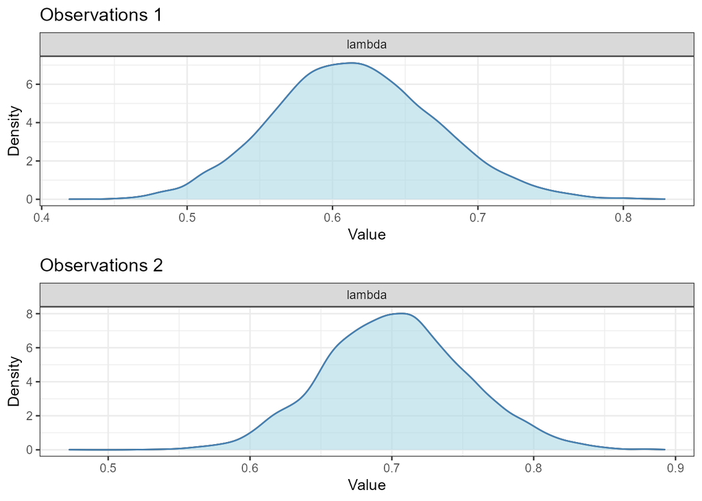

```r
ggarrange(chain_e5_1$density(title=tit.1), chain_e5_2$density(title=tit.2), ncol=1, nrow=2)
```

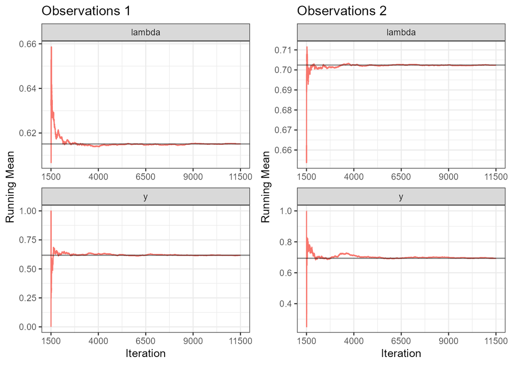

```r
ggarrange(chain_e5_1$running(title=tit.1), chain_e5_2$running(title=tit.2), ncol=2, nrow=1)
```

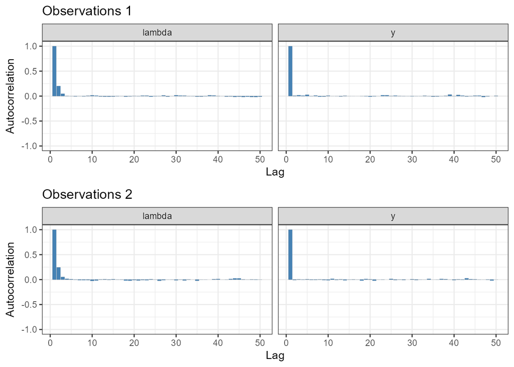

```r
ggarrange(chain_e5_1$autocorrelation(title=tit.1), chain_e5_2$autocorrelation(title=tit.2), ncol=1, nrow=2)
```

```r
ggarrange(
  chain_e5_1$inference(y.cred.int=1.5, subtitle=tit.1, xlim=c(0.45, 0.9), ylim=c(0, 8)),
  chain_e5_2$inference(y.cred.int=1.5, subtitle=tit.2, xlim=c(0.45, 0.9), ylim=c(0, 8)),
  ncol=1, nrow=2
)
```

[figure not shown]

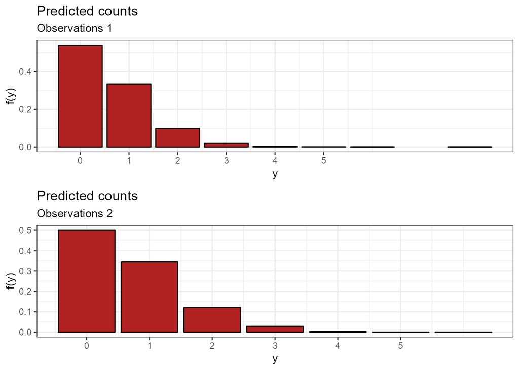

```r
ggarrange(
  chain_e5_1$prediction(x.plot.max=5, subtitle=tit.1),
  chain_e5_2$prediction(x.plot.max=5, subtitle=tit.2),
  ncol=1, nrow=2
)
```

```r
ggarrange(
  chain_e5_1$correlation(x.min=0.4, x.max=1, y.min=0, y.max=6, subtitle=tit.1),
  chain_e5_2$correlation(x.min=0.4, x.max=1, y.min=0, y.max=6, subtitle=tit.2),
  ncol=1, nrow=2
)
```

[figure not shown]

# Exercise 6

Analyze the data of Exercise 3 using a MCMC with JAGS (solve points b and c).

To solve this exercise I can use the same JAGS model defined for exercise 4.

### Run MCMC and plot the results

```r
data <- NULL
data$X <- 11       # number of observations
data$n <- 116      # number of patients screened
data$n_next <- 10  # predictions (10 more data)

data$alpha <- 1
data$beta  <- 10

jm <- jags.model(file=modelpath_e4, data=data, n.chains=1, n.adapt=500)
update(jm, 1000)
chain <- coda.samples(jm, c("p", "y"), n.iter=10000)
print(summary(chain))
```

```
##
## Iterations = 1501:11500
## Thinning interval = 1
## Number of chains = 1
## Sample size per chain = 10000
##
## 1. Empirical mean and standard deviation for each variable,
##    plus standard error of the mean:
##
##     Mean     SD Naive SE Time-series SE
## p 0.0948 0.0256 0.000256       0.000325
## y 0.9467 0.9568 0.009568       0.009932
##
## 2. Quantiles for each variable:
##
##     2.5%    25%    50%   75% 97.5%
## p 0.0508 0.0768 0.0927 0.111  0.15
## y 0.0000 0.0000 1.0000 1.000  3.00
```

```r
# Correlation matrix
cat("Correlation matrix: \n")
```

```
## Correlation matrix:
```

```r
as.data.frame(as.mcmc(chain)) %>%
  cor() %>%
  print()
```

```
##         p       y
## p 1.00000 0.25555
## y 0.25555 1.00000
```

```r
chain_e6 <- chainR6$new(chain, param='p')
```

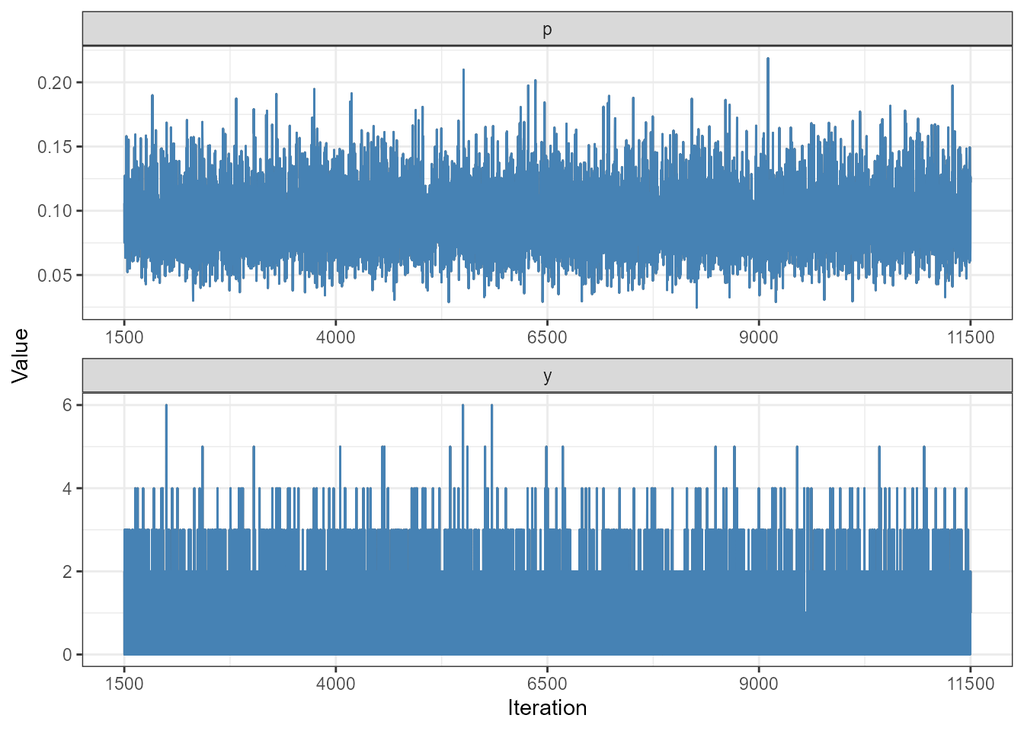

```r
chain_e6$traceplot()
```

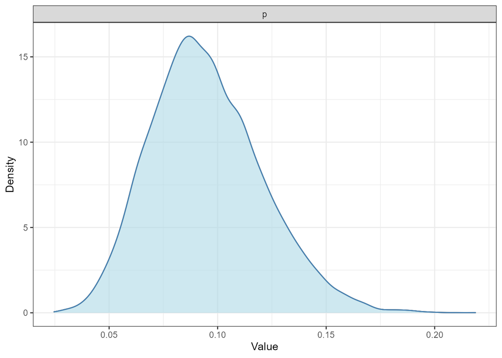

```r
chain_e6$density()
```

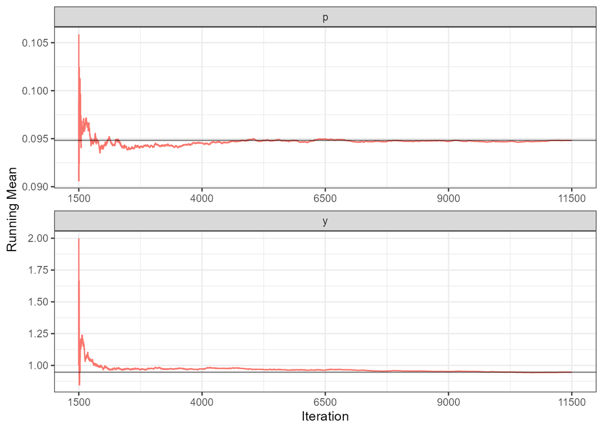

```r
chain_e6$running()
```